# task15

Deivydas Sinkevičius

2016 m lapkritis 8 d

**Jums reikia atlikti paprastą tiesinę regresiją. Prognozuojamas kintamasis y, regresosrius x. Duomenų failas:**

https://github.com/1vbutkus/Econometrics1/blob/master/task15/data.csv

Iš pradžių nuskaitome duomenis ir įsitikiname kad failas nėra tuščias:

```r
data=read.csv('data.csv', stringsAsFactors = FALSE)
data
```

```
##       X        y           x
## 1     1 2.208648  0.39741723
## 2     2 2.160826  0.36481927
## 3     3 2.189213  0.36532382
## 4     4 2.537114  0.67062463
## 5     5 2.559754  0.67302029
## 6     6 2.042661  0.07627736
## 7     7 1.997480  0.02681457
## 8     8 2.001354 -0.22643038
## 9     9 2.057864  0.07286347
## 10   10 2.684328  0.77840337
## 11   11 2.240185  0.42138873
## 12   12 2.124323  0.27993037
## 13   13 2.170238  0.35318671
## 14   14 2.669823  0.77922884
```

[output cut: 86 more lines]

**1. Įvertinti paprastosios tiesinės regresijos modelį. Pateikti modelio `summary` ir pakomentuoti ką reiškia gauti skaičiai. Kaip interpretuoti gautus rezultatus?**

Su funkcija ‘lm’ įvertiname tiesinės regresijos modelį pateiktiems duomenims ir pateikiame modelio ‘summary’:

```r
x<-data$x
y<-data$y
mod<-lm(y~x)
summary(mod)
```

```
##
## Call:
## lm(formula = y ~ x)
##
## Residuals:
##      Min       1Q   Median       3Q      Max
## -0.14936 -0.08639 -0.04626  0.08815  0.21943
##
## Coefficients:
##             Estimate Std. Error t value Pr(>|t|)
## (Intercept)  2.06843    0.01205  171.58   <2e-16 ***
## x            0.50934    0.03225   15.79   <2e-16 ***
## ---
## Signif. codes:  0 '***' 0.001 '**' 0.01 '*' 0.05 '.' 0.1 ' ' 1
##
## Residual standard error: 0.1065 on 98 degrees of freedom
## Multiple R-squared:  0.7179, Adjusted R-squared:  0.715
## F-statistic: 249.4 on 1 and 98 DF,  p-value: < 2.2e-16
```

Išvestyje matome:

1. Iškviestos funkcijos formulė
2. Likutis (“Residuals”), kuriame pateikiami minimumo (“Min”), pirmojo kvantilio (“1Q”), medianos (“Median”), trečiojo kvantilio (“3Q”), maksimumo (“Max”) taškai.“Residuals”" rodo paklaidą, kiek prognozuojami duomenys gali skirtis nuo stebimų duomenų, t.y. kaip duomenys yra išsibarstę apie regresijos tiesę.
3. Koeficientai(“Coefficients”): įvertis (“Estimate”), standartinė paklaida (“Std. Error”), Stjudento kriterijaus statistikos t reikšmė (“t value”), tikimybė (" Pr(>|t|)“)
4. Reikšmingumo kodai (Signif. codes), kitaip sakant tikimybės kategorijos
5. “Residual standard error” rodo stebimų duomenų nuokrypį nuo įvertinto jų modelio
6. Pakeltas R^2 ir pritaikytas R^2 parodo kiek mūsų modelis yra tinkamas. Kuo R^2 arčiau 1, tuo modelis geriau įvertina duomenis.
7. Fišerio skirstinio statistika (“F-statistic”), tikimybė (“p-value”)

**2. Padarykite modelio prognozes taškuose $0, 0.3, 0.5$.**

```r
newx<-c(0,0.3,0.5) #Susikuriame vektorių newx, kuriame nurodome šiuos taškus
newy = predict(mod, newdata=data.frame(x=newx)) #Randame 'newx' atitinkamą koordinatę 'newy'
newy
```

```
##        1        2        3
## 2.068428 2.221230 2.323098
```

**3. Išbrėžkite kintamųjų sklaidos diagramą kartu su tiesinės regresijos tiese ir naujomis prognozėmis. Grafiką pateikite su pilna legena, kurioje būtų nurodyti visi žymėjimai.**

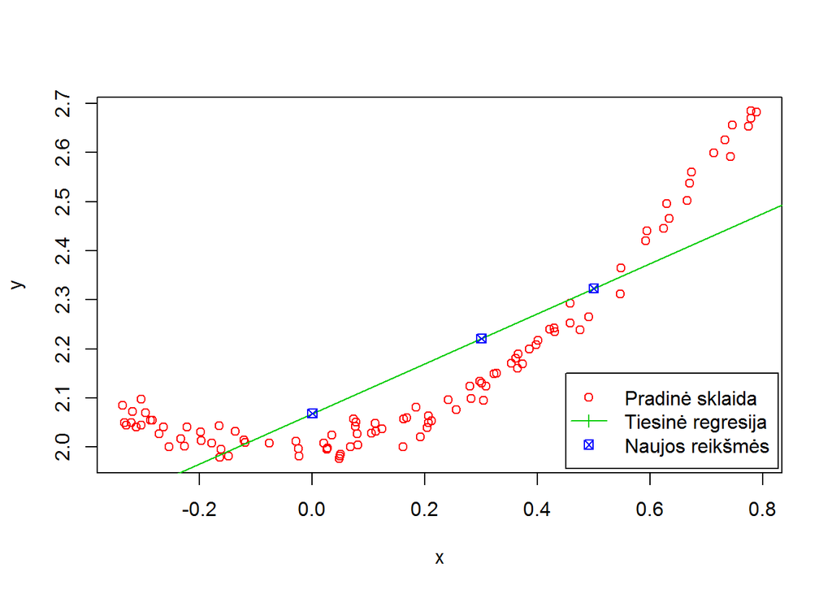

```r
plot(x, y, xlab = "x", ylab = "y", pch = 1, col = '2')  # Nubraižome pirminių duomenų sklaidą
abline(mod, pch = 3, col = '3')  # Nubrėžiame tiesinės regresijos tiesę
points(newx, newy, pch = 7, col = '4')  # Pažymime įsivestus taškus grafike
legend( 0.45, 2.15, c("Pradinė sklaida", "Tiesinė regresija", "Naujos reikšmės"), lty = c(0, 1, 0), pch = c(1, 3, 7), col = c('2','3','4'))  # Susikuriame legendą
```

**4. Pakomentuokite ar tinkamas šis modelis duotiems duomenims. Ar galite pateikti tobulinimo pasiūlymų?**

```r
(summary(mod))$r.squared
```

```
## [1] 0.7178925
```

R^2 yra statistinis matas, kuris parodo, kaip duomenys yra „arti“ regresinės tiesės. R^2 reikšmė yra intervale [0,1], tad kuo matas arčiau 1 - tuo regresinė tiesė labiau prisitaikiusi prie duomenų.

Šis modelis nėra labai tinkamas duotiems duomenims, nes matome, kad gautas skaičius(0.7178925) nėra labai arti 1.

Rėmiausi task11(https://github.com/sindeivydas/Econometrics1/tree/master/task11) ir http://ekonometrija.lt/blog/tiesin%C4%97-regresija